# WTI Options Portfolio: Full Greek P&L Attribution

Individual Project

Author

Soumer Seifeddine

Published

March 5, 2026

# Description

You are a risk analyst at an energy trading desk. The desk holds a portfolio of WTI crude oil options — specifically, options on NYMEX CL futures contracts.

Your role is to:

- Build a full-Greek P&L attribution framework: the standard tool used on trading desks to explain daily P&L movements across **Delta** (directional exposure), **Gamma** (curvature), **Vega** (volatility sensitivity), **Vanna** (sensitivity of delta to volatility), and **Theta** (time decay).
- You are expected to understand contracts and use the right option model and specifications in the `RTL` package.
- Tell me in your own words the portfolio’s risk profile, how the Greeks interact, and what this means for a desk managing this book in practice.
- No AI use in any shape or form and assignment submitted should be a github repo that I can clone and assess.

# Objective

1. Compute numerical Greeks for each position and for the overall portfolio across the full WTI price range ($50–$100/bbl).
2. Interpret the portfolio’s mark-to-market profile and explain how changing Gamma across strike levels affects delta-hedging in practice.
3. Build a complete P&L attribution framework — Delta, Gamma, Vega, Vanna, and Theta — and verify it accurately explains overnight P&L under a realistic market move.
4. Critically evaluate where and why the linear/quadratic approximation breaks down as spot moves away from current market.

# Exposure

WTI Options Portfolio

Three-way collar: long put spread + short OTM call | F₀ = $73/bbl

| Position | Type | Strike K ($/bbl) | Maturity | Impl. Vol | Contracts |
| --- | --- | --- | --- | --- | --- |
| P1 | Put | 70.00 | 3M | 35.00% | +2,000 long |
| P2 | Put | 55.00 | 3M | 42.00% | -2,000 short |
| P3 | Call | 80.00 | 3M | 30.00% | -2,000 short |

**Market parameters**: current WTI futures price F₀ = **$73.00/bbl**, risk-free rate r = **4.00%** (annualised, continuously compounded).

Select the appropriate pricing model from the `RTL` package for options on WTI crude oil futures. Consider the nature of the underlying contract — a NYMEX CL futures — when choosing the model and setting its cost-of-carry parameter.

# Question 1 (9 points)

For **each position**, compute the following Greeks **numerically** using central differences evaluated at `F_0`:

- **Delta** (∂V/∂F)
- **Gamma** (∂²V/∂F²)
- **Vega** (∂V/∂σ)
- **Theta** (∂V/∂T)

**Step size selection**: For each Greek, choose an appropriate finite-difference step size and explain your reasoning. A good step is small enough that the finite difference accurately approximates the true derivative, but not so small that floating-point subtraction errors dominate. Consider the natural scale of each risk factor (price in $/bbl, vol as a decimal, time in years) and any special considerations for the short-dated options in this portfolio.

**Answer**

- **Delta**: Because Delta measure the option’s sensitivity to the underlying CL future, and the minimum price fluctuation per the CME is 1 cent per barrel, then the step size should be at least 1 cent. But, to avoid subtraction errors, I checked the listed CL futures options and found that they have strike prices that vary in 50 cent increments I will choose the step size to be 25 cents per barrel. The idea is that If a future moves 25 cents up or down, then an option will either move deeper ITM, deeper OTM, or close to ITM. This will hopefully be a sufficient step size that will not smooth the curve in areas where delta is high and sensitive to price moves.
- **Gamma**: Follows the same logic and step size as gamma
- **Vega**: The options in this portfolio all expire in 3 months, meaning that they are on a steeper end of the volatility smile. That being said, the calls and puts have very different implied vol - the puts have a higher IV so that means that the market values a steep drop in price more than a sharp increase. I would assume that the vegas would also be differnet and that the portfolio vega would be largely drive by the puts as they currently stand, so I want to explore having the step size scale with IV while remaining proportional across the positions. (i.e wih a higher IV we can use a higher step size to capture more of the trend of the smile at that point. So we use 3% * IV as the step size). For now, I will use a 1% step size in IV across the portfolio.
- **Theta**: For Theta, becasue this measures the sensitivity to passage of time, I will use 1 calendar day as the step size instead of using 1 trading day. Becuse even if the markets are closed, time still goes by and T2M decreases, so I believe that 1 calendar day is an adequate time step.

**Dollar scaling**: Each raw numerical derivative gives the option price change **per barrel** for a unit move in the risk factor. To express the Greek as a total dollar P&L impact for a position, multiply by `n × mult`, where `n` is the signed contract count (positive = long, negative = short) and `mult = 1,000 bbl/contract`. For example, a delta of 0.50/bbl for a 3,000-contract long position means the desk gains or loses 0.50 × 3,000 × 1,000 = $1,500,000 per $1/bbl move in WTI.

Create plots showing each Greek vs. futures price over F ∈ [50, 100], with one line per position.

**d.** Compute the **portfolio mark-to-market (MTM)** value and **portfolio Gamma** across F ∈ [50, 100]. Plot them on two separate panels. In 3–5 sentences, explain:

- What the MTM profile shape reveals about the portfolio’s net directionality and curvature.
- Where portfolio Gamma is highest and lowest across the price range, and why those regions correspond to specific positions.
- What the changing Gamma means for a delta-hedger rebalancing daily as WTI moves through the $50–$100 range.

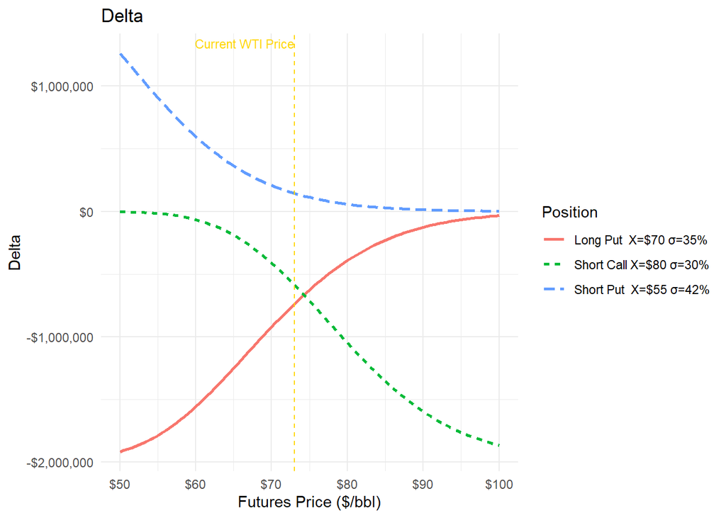

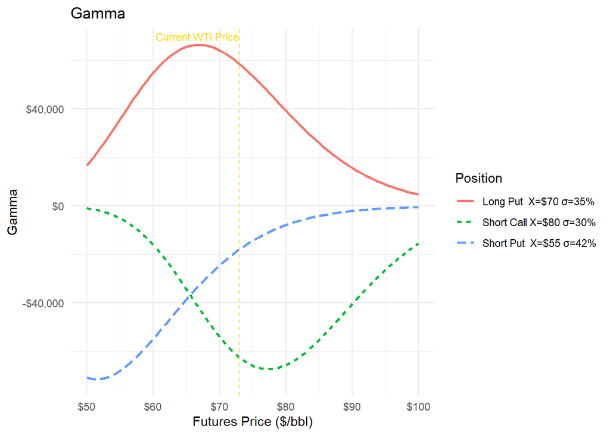